# Boerhaave 2026: Using R for data analysis

# Data structures 1/2

## Variables and assignment (lecture) 👩‍🏫

*Needs:* “arithmetic”, “console”, “comment”.  
*Gives:* “<-”, “=”, “assignment”.

### Variable and its value

A **variable** stores a **value**, which can be explicitly provided or a result of a calculation.

Type the following lines in the `Console`. Observe changes in the `Environment` pane after each Enter.

```r
gardenWidth <- 5                         # Assign 5 to the variable gardenWidth
gardenLength <- 6                        # Assign 6 to the variable gardenLength

gardenArea <- gardenWidth * gardenLength # Calculate the area of the garden
#                                        # Assign the result to the variable gardenArea
```

To find out what the value of a variable is, type its name:

```r
gardenArea
```

```
[1] 30
```

A frequent error is to ask for a non-existing variable. Type to see the error:

```r
gggardenArea
```

```
Error: object 'gggardenArea' not found
```

### Assignment operator

The arrow symbol `<-` is called the **assignment operator**:

```r
x <- 5                    # Assign 5 to x
```

You may also use the equal sign `=` for assignment:

```r
y = 6                     # Assign 6 to y
```

### No assignment, no change

Variable assignment is needed to store a new value or to replace a previous one.  
When there is no assignment, the result is printed to screen and lost.

For example, the sequence of statements below is the wrong way to “increase `x` by one”.  
The result is calculated but it is not stored.  
Type these commands line by line. Observe when value of `x` changes in the `Environment` pane:

```r
x <- 5                    # Assign 5 to x
x                         # Prints x (the current value is 5)
```

```
[1] 5
```

```r
x + 1                     # Calculate x+1, prints 6
```

```
[1] 6
```

```r
x                         # Prints x (the value is still 5; no assignment above)
```

```
[1] 5
```

Here is the correct way to “increase `x` by one”.  
Type these commands line by line. Observe when value of `x` changes in the `Environment` pane:

```r
x <- 5                    # Assign 5 to x
x                         # Prints x (the current value is 5)
```

```
[1] 5
```

```r
x <- x + 1                # Calculate x+1 and assign the result to x
x                         # Prints x (the value is 6)
```

```
[1] 6
```

*Remember:* no assignment, no change.

### Where variables are stored

The variables are stored in R memory and RStudio shows them in the `Environment` pane.  
When you close RStudio, all variables are lost.

We will learn how to write **scripts** to store commands used to calculate variable values. The scripts provide **reproducibility** (they document how the results were calculated).

*Note:* If you notice that some variables are present in the Environment pane just after you have started RStudio, then it means that you load state of the previous session. Follow the instructions in the Calculator lecture to disable this behavior in Global Options.

### Valid variable names

Variable names in R are case sensitive (all other symbols also).  
Note that `_` is allowed in variable names.  
Numbers (not at the beginning) are allowed too.

Here are some examples (and each one is a different variable):

```r
gardenLength <- 6
garden_length <- 6
gArDeNlEnGtH <- 6     # valid, but bad, don't use this
garden.length <- 6    # valid, but may lead to mistakes, don't use this

len1 <- 5             # len1 is good, 1len is wrong
len2 <- 6
```

Choose meaningful variable names for readable scripts.

Naturally, there are some limitations. Do not use variable names:

- containing a space (possible, but not recommended)
- containing any of `@#!%$^()-+=!~?,<>}{][`
- `for`, `while`, `repeat`, `if`, `else`, `TRUE`, `FALSE`, `Inf`, `NA`, `NaN`, … (R reserved names)

### Autocomplete names

RStudio provides autocomplete feature, useful for long variable names.

Start typing the first letters of a (variable) name and press `Tab`.

## Vectors (lecture) 👩‍🏫

*Needs:* “console”, “arithmetic”, round, pi.  
*Gives:* “Vectors”, c, length, sum, mean, median, “:”, seq, TRUE, FALSE, NA, “RelOps”, is.na, class, str, “[…]”, names.

A **vector** is a container of (multiple) elements:

- All elements must be of the same type (e.g. all are numbers).
- The elements are kept at numbered positions (there is the first element, second, …).
- The elements might be given names (first may be named “Jay”, second “Gloria”, …).

Some examples of a vector (and its **type**):

- Heights of students (a vector of numbers, `numerical`).
- Names of students (a vector of texts, `character`).
- Whether students have siblings (a vector of FALSE/TRUE values, `logical`).
- Eye color of students (a vector of values from a limited choice list, `factor`).

Vector is the primary data structure of the R language.  
*Note:* A table (`data.frame` or `tible` discussed later) can be seen as a collection of vectors (columns).

### Numerical vector

A vector of numbers you can create with the **combine** function `c`. Arithmetic operations and many functions work on vectors elementwise.

```r
radiuses <- c(3.5, 6, 7, 1+1)
radiuses                    # print the vector
```

```
[1] 3.5 6.0 7.0 2.0
```

```r
radiuses + 2                # add 2 to each element
```

```
[1] 5.5 8.0 9.0 4.0
```

Vector elements can have **names**, and the names are carried over in operations:

```r
radiuses <- c(typical=3.5, large=6, huge=7, tiny=1+1)
radiuses
```

```
typical   large    huge    tiny
    3.5     6.0     7.0     2.0
```

```r
areas <- pi*radiuses^2
areas
```

```
  typical     large      huge      tiny
 38.48451 113.09734 153.93804  12.56637
```

```r
round( areas, 1 )           # round to one decimal place
```

```
typical   large    huge    tiny
   38.5   113.1   153.9    12.6
```

Some functions summarize a vector to a single number:

```r
length( radiuses )          # number of elements in the vector
```

```
[1] 4
```

```r
sum( radiuses )             # sum of elements
```

```
[1] 18.5
```

```r
mean(radiuses)              # mean of elements
```

```
[1] 4.625
```

```r
median(radiuses)            # median of elements
```

```
[1] 4.75
```

### Integer sequence

A simple regular sequence you can create with `:` (**colon operator**). Try:

```r
positions <- 5:15
positions
```

```
 [1]  5  6  7  8  9 10 11 12 13 14 15
```

You can also use the function `seq`, which allows to specify the step:

```r
spacedPositions <- seq(5,15,3)
spacedPositions
```

```
[1]  5  8 11 14
```

### Character vector

A **character** vector, so a vector of any texts, you may also create with the **combine** function `c`. Both single quotes (`'word'`) and double quotes (`"word"`) are allowed (must be identical at the beginning and the end of a text):

```r
actors <- c( "Jay", "Gloria", "Claire", "Phil", 'Mitchell', 'Cameron' )
actors
```

```
[1] "Jay"      "Gloria"   "Claire"   "Phil"     "Mitchell" "Cameron"
```

For example, a character vector is used to store names of vector elements. Use `names` function to access them:

```r
radiuses <- c(typical=3.5, large=6, huge=7, tiny=1+1)
names( radiuses )                                   # get the names
```

```
[1] "typical" "large"   "huge"    "tiny"
```

```r
names( radiuses ) <- c("TYP", "LRG", "HUG", "TNY")  # set some new names
radiuses
```

```
TYP LRG HUG TNY
3.5 6.0 7.0 2.0
```

### Logical vector

In R the following words denote **logical** values: `FALSE` and `TRUE`. You may also create a logical vector with the **combine** function `c`, but typically, logical vectors are results of logical conditions:

```r
temperatures <- c( 36.4, 35.8, 37.2, 38.9, 40.2, 37.1, 35.8, 34.8 )
temperatures > 36.6                    # the result is a logical vector
```

```
[1] FALSE FALSE  TRUE  TRUE  TRUE  TRUE FALSE FALSE
```

Such a logical vector can be used to **filter** elements of another vector:

```r
temperatures[ temperatures > 36.6 ]    # greater than 36.6
```

```
[1] 37.2 38.9 40.2 37.1
```

```r
temperatures[ temperatures <= 36.6 ]   # less or equal to 36.6
```

```
[1] 36.4 35.8 35.8 34.8
```

```r
temperatures[ temperatures != 35.8 ]   # not equal to 35.8
```

```
[1] 36.4 37.2 38.9 40.2 37.1 34.8
```

```r
sel <- temperatures == 35.8
temperatures[ sel ]                    # exactly equal to 35.8
```

```
[1] 35.8 35.8
```

```r
temperatures[ !sel ]                   # NOT (exactly equal to 35.8), same as !=
```

```
[1] 36.4 37.2 38.9 40.2 37.1 34.8
```

```r
sel <- temperatures > 36 & temperatures < 38
temperatures[ sel ]                    # larger than 36 AND less than 38
```

```
[1] 36.4 37.2 37.1
```

```r
sel <- temperatures <= 35 | temperatures >= 40
sel                                    # less or equal to 35 OR greater or equal to 40
```

```
[1] FALSE FALSE FALSE FALSE  TRUE FALSE FALSE  TRUE
```

The function `sum` might be used on a logical vector to count how many elements are `TRUE`:

```r
sum( temperatures > 36.6 )
```

```
[1] 4
```

### Missing values

Use `NA` (**not available**) to represent a single **missing value**. Missing values can appear in vectors of any type. When a missing value appears in a calculation, the result is usually also a missing value:

```r
radiuses <- c(3.5, 6, NA, 7, 1+1)
round( pi*radiuses^2, 1 )
```

```
[1]  38.5 113.1    NA 153.9  12.6
```

Descriptive statistics functions like `mean`, `min`, `max`, `sum` require the argument `na.rm=TRUE` to ignore missing values:

```r
sum( radiuses, na.rm=TRUE )
```

```
[1] 18.5
```

```r
mean( radiuses, na.rm=TRUE )
```

```
[1] 4.625
```

The function `is.na` returns a logical vector with `TRUE` at positions corresponding to `NA`s:

```r
radiuses
```

```
[1] 3.5 6.0  NA 7.0 2.0
```

```r
is.na( radiuses )
```

```
[1] FALSE FALSE  TRUE FALSE FALSE
```

When combined with the function `sum`, it **counts the number of missing values** in a vector:

```r
sum( is.na( radiuses ) )
```

```
[1] 1
```

Or, when **negated** (with `!` symbol) it **counts the number of not missing values** in a vector:

```r
sum( !is.na( radiuses ) )
```

```
[1] 4
```

To select all non-missing elements do:

```r
radiuses[ !is.na( radiuses ) ]
```

```
[1] 3.5 6.0 7.0 2.0
```

### Vector elements

Use square brackets to **select** an element from a vector. The first element is at position 1. The following selects an element from the second position:

```r
temperatures <- c( 36.4, 35.8, 37.2, 36.9, 36.1 )
temperatures[2]
```

```
[1] 35.8
```

The last element can be selected as follows:

```r
temperatures[ length( temperatures ) ]
```

```
[1] 36.1
```

To **select multiple elements** at once:

```r
temperatures[ c(3,1) ]   # third and first
```

```
[1] 37.2 36.4
```

```r
positions <- 2:4
temperatures[positions]  # second, third, and fourth
```

```
[1] 35.8 37.2 36.9
```

```r
101:128
```

[output not shown]

When a vector is **named**, the names can also be used in selection:

```r
temperatures <- c( Day1=36.4, Day2=35.8, Day3=37.2, Day4=36.9, Day5=36.1 )
temperatures["Day3"]
```

```
Day3
37.2
```

```r
selDays <- c( "Day4", "Day3" )
temperatures[ selDays ]
```

```
Day4 Day3
36.9 37.2
```

### Structure and class

Use `class` to find what **type** of a vector is stored in a variable.  
More information about the structure of a vector can be obtained with the function `str`.

```r
positions <- 5:15
temperatures <- c( 36.4, 35.8, 37.2, 38.9, 40.2, 37.1, 35.8, 34.8 )
actors <- c( "Jay", "Gloria", "Claire", "Phil", 'Mitchell', 'Cameron' )
isFever <- temperatures > 36.6
```

```r
class( temperatures )
```

```
[1] "numeric"
```

```r
class( positions )
```

```
[1] "integer"
```

```r
class( actors )
```

```
[1] "character"
```

```r
class( isFever )
```

```
[1] "logical"
```

```r
str( temperatures )
```

```
 num [1:8] 36.4 35.8 37.2 38.9 40.2 37.1 35.8 34.8
```

```r
str( positions )
```

```
 int [1:11] 5 6 7 8 9 10 11 12 13 14 ...
```

```r
str( actors )
```

```
 chr [1:6] "Jay" "Gloria" "Claire" "Phil" "Mitchell" "Cameron"
```

```r
str( isFever )
```

```
 logi [1:8] FALSE FALSE TRUE TRUE TRUE TRUE ...
```

## Estimate weights (exercise) 📖

*Needs:* “Vectors”.  
*Gives:* sort.  
*Practices:* c, round, sort.

Let’s assume that we want to estimate the weights of certain individuals. All we have is the following picture:

[figure not shown]

Let’s also assume that the individuals in the picture have healthy BMI and that we can roughly estimate their weights based on their heights. The heights in the picture are expressed in imperial units, e.g. 5’0’’ stands for 5 feet and 0 inches, where foot=12’’ and 1’’=2.54cm.

1. Create a vector of heights of the individuals in metre based on your rough estimate of inches in the picture.
2. Calculate the weights from the obtained heights by the equation $Weight_{kg}=(Height_m-1)*100$.
3. Calculate the mean of obtained weights rounded to 1 decimal.
4. Include two additional weights 99 and 68 kg into your data.
5. Sort the weights in decreasing order.

**Solution…**

```r
heights_metre <- c(5*12+7,6*12+2,6*12+6,6*12+2,6*12)*2.54/100 # rough estimate in inches and conversion to meter
weights <- (heights_metre-1)*100                              # weight estimate
round( mean( weights ), 1 )                                   # mean weight rounded to 1 decimal
weights <- c(weights, 68, 99)                                 # adding additional weights
sort(weights, decreasing = TRUE)                              # sorting
```

## Monthly spendings (exercise) 📖

*Needs:* “Vectors”.  
*Practices:* c, names, “[…]”.

Below is the monthly spending of different categories in the first quarter:

```r
spendJan <- c( transport = 50, rent = 500, sport = 33, food = 200, clothes = 100 )
spendFeb <- c( rent = 550, clothes = 30, food = 130, sport = 55, transport = 90 )
spendMar <- c( rent = 600, food = 180, transport = 70, clothes = 280, sport = 50 )
```

What is the total spending per category?

**Solution…**

```r
nm <- names( spendJan )
spendJan[ nm ] + spendFeb[ nm ] + spendMar[ nm ]
```

## Vectors, continuation (lecture) 👨‍🏫

*Needs:* “Vectors”, “:”, length, TRUE, FALSE, “RelOps”.  
*Gives:* “strsplitExample”, “[…]”, sort, unique, “==”, “!=”, any, all, which, duplicated, “[logical]”, paste, paste0.

### Splitting a text

Splitting a single text at a certain character (here `:`) into a vector of words can be achieved as follows.  
(*Note:* this is a more advanced example, the `strsplit`, `[[...]]` and lists will be introduced later.)

```r
# Here is a single text with many words separated by :
text <- "apple:banana:lemon:apple:raspberry:pear:apple:lemon"

# More advanced code, which separated text at : into a vector of words
fruits <- strsplit( text, ":" )[[1]]

# Now, the fruits vector contains the words (a character vector)
fruits
```

```
[1] "apple"     "banana"    "lemon"     "apple"     "raspberry" "pear"
[7] "apple"     "lemon"
```

```r
length( fruits )
```

```
[1] 8
```

Fruits from the third to the fifth position are:

```r
fruits[ 3:5 ]
```

```
[1] "lemon"     "apple"     "raspberry"
```

### Sorting

And here is the sorted list of `fruits`:

```r
sort( fruits )
```

```
[1] "apple"     "apple"     "apple"     "banana"    "lemon"     "lemon"
[7] "pear"      "raspberry"
```

```r
sort( fruits, decreasing = TRUE )
```

```
[1] "raspberry" "pear"      "lemon"     "lemon"     "banana"    "apple"
[7] "apple"     "apple"
```

The `sort` function can also be used to sort numbers:

```r
numbers <- c( 3, 1, 4, 1, 5, 9, 2, 6, 5, 3, 5 ) # some numbers
sort( numbers )
```

```
 [1] 1 1 2 3 3 4 5 5 5 6 9
```

```r
sort( numbers, decreasing = TRUE )
```

```
 [1] 9 6 5 5 5 4 3 3 2 1 1
```

### Unique/duplicated elements

Here are the `unique` fruits:

```r
unique( fruits )
```

```
[1] "apple"     "banana"    "lemon"     "raspberry" "pear"
```

This logical vector tells which elements has appeared before:

```r
duplicated( fruits )
```

```
[1] FALSE FALSE FALSE  TRUE FALSE FALSE  TRUE  TRUE
```

These elements are at the following positions:

```r
which( duplicated( fruits ) )
```

```
[1] 4 7 8
```

Similarly for `numbers`:

```r
numbers
```

```
 [1] 3 1 4 1 5 9 2 6 5 3 5
```

```r
sort( unique( numbers ) )      # unique numbers, sorted
```

```
[1] 1 2 3 4 5 6 9
```

```r
duplicated( numbers )          # has this element appeared before: TRUE/FALSE
```

```
 [1] FALSE FALSE FALSE  TRUE FALSE FALSE FALSE FALSE  TRUE  TRUE  TRUE
```

```r
which( duplicated( numbers ) ) # at which positions are duplicates
```

```
[1]  4  9 10 11
```

### All and any

The following logical vector shows which fruits are `apple` (or not `apple`):

```r
fruits
```

```
[1] "apple"     "banana"    "lemon"     "apple"     "raspberry" "pear"
[7] "apple"     "lemon"
```

```r
fruits == "apple"            # is this element "apple": TRUE/FALSE
```

```
[1]  TRUE FALSE FALSE  TRUE FALSE FALSE  TRUE FALSE
```

```r
fruits != "apple"            # is this element not "apple": TRUE/FALSE
```

```
[1] FALSE  TRUE  TRUE FALSE  TRUE  TRUE FALSE  TRUE
```

Are there `any` `apple` elements in the vector:

```r
any( fruits == "apple" )     # is there any element "apple": a single TRUE or FALSE
```

```
[1] TRUE
```

Or, are all fruits not `apple`:

```r
all( fruits != "apple" )     # are all elements not "apple": a single TRUE or FALSE
```

```
[1] FALSE
```

Some examples with `numbers`:

```r
numbers
```

```
 [1] 3 1 4 1 5 9 2 6 5 3 5
```

```r
numbers >= 5 & numbers < 7        # is this element greater/equal 5 and less than 7: TRUE/FALSE
```

```
 [1] FALSE FALSE FALSE FALSE  TRUE FALSE FALSE  TRUE  TRUE FALSE  TRUE
```

```r
any( numbers >= 5 & numbers < 7 ) # is there any element greater/equal 5 and less than 7, a single TRUE or FALSE
```

```
[1] TRUE
```

### Selecting elements

What are the other fruits than apples (duplicates possible):

```r
fruits[ fruits != "apple" ]
```

```
[1] "banana"    "lemon"     "raspberry" "pear"      "lemon"
```

```r
fruits[ !(fruits == "apple") ]
```

```
[1] "banana"    "lemon"     "raspberry" "pear"      "lemon"
```

At which positions is the `lemon`:

```r
which( fruits == "lemon" )    # not a logical vector, but integer positions
```

```
[1] 3 8
```

What are the `numbers` which are smaller than 5 or greater/equal 7:

```r
numbers[ numbers < 5 | numbers >= 7 ]
```

```
[1] 3 1 4 1 9 2 3
```

### Producing text by merging elements

For reporting there is often a need to merge elements into a single text:

```r
uqFruits <- unique( fruits )                       # character vector, several elements
uqFruitsTxt <- paste( uqFruits, collapse = ", " )  # single text: fruit names separated by ,
txt <- paste0("Unique fruits: ", uqFruitsTxt, ".") # single text: a full sentence
txt
```

```
[1] "Unique fruits: apple, banana, lemon, raspberry, pear."
```

Another example with `numbers`:

```r
paste0( sort( unique( numbers ) ), collapse="<" )
```

```
[1] "1<2<3<4<5<6<9"
```

## Descriptive statistics (exercise) 📖

*Needs:* “Vectors”, sum, min, max, median, fivenum, head, sort, tail, NA, “RelOps”.  
*Practices:* length, sum, max, min, median, fivenum, head, tail, sort, sum, NA, “RelOps”.

You are given a numerical vector `heights` representing the heights(cm) of a group of individuals. For some reasons some of these individuals have missing value (`NA`) for their heights.

```r
heights <- c(180, 170,  NA,  NA, 174, 178, 169, 174,  NA, 174, 170, 174, 173,
  168, 170, 166,  NA, 187, 170, 164,  NA, 167, 178, 165, 164)
```

**Solution…**

```r
# How many individuals
length(heights)

# How many individuals have their height not reported
sum(is.na(heights))

# Height range
max(heights, na.rm=TRUE)
min(heights, na.rm = TRUE)
range( heights, na.rm=TRUE)

# Middle height
median(heights, na.rm=TRUE)

# Fivenum gives min/median/max and two quartiles (see ?fivenum)
fivenum(heights)

# 5 lowest and 5 largest heights
head(sort(heights), 5)
tail(sort(heights), 5)

# Number of individuals within the range (175,180), uses & (logical AND)
sum(heights > 175 & heights < 180, na.rm=TRUE)

# Number of individuals at most 175 cm or at least 180 cm tall, uses | (logical OR)
sum(heights <= 175 | heights >= 180, na.rm=TRUE)

# Valid heights, uses negation of is.na result
validHeights <- heights[!is.na(heights)]
```

## Snacks in a kindergarden (exercise) 📖

*Needs:* “strsplitExample”, length, “[…]”, “:”, sort, unique, “==”, “!=”, any, all, which, duplicated.  
*Practices:* length, “==”, any, unique, duplicated, sort, which.

In a kindergarten there are children, each of a different name. The children are eating snacks. Each child should get exactly one snack. Here, in `nms`, there are the names of the children in the order of picking snacks (every time a single snack was picked):

```r
nmsTxt <- "Oliver Mia Walter Charlie Liam Kate Hank Gina Zoe Eva Xena Tom Nora Jack Cathy Helen Yuri Rita Ivan Ben Adam Daisy Liam Quinn George Sam Vera Pam Eve Bob Alice Frank David Fred Yuri Mia Yuri Ursula"
nms <- strsplit( nmsTxt, " " )[[1]]  # split the text into words, will be introduced later
```

1. How many snacks were picked?
2. How many kids picked a snack?
3. Did `Jane` get a snack?
4. Are there children who picked a snack more than once?
5. What are the names of the children who picked a snack more than once (but don’t mention any child twice)?
6. Can you produce an alphabetical list of children names, skipping duplicates?
7. Assuming that `Eva` picked exactly one snack: how many snacks were picked before `Eva` did, and how many after?
8. `Fred` also took just one snack: what are the unique names of the children who picked a snack after `Fred`?

**Solution…**

```r
# num of snacks taken
length(nms)

# num of kids
length(unique(nms))

# Jane got a snack?
any(nms == "Jane")

# more snacks picked than kids?
length(unique(nms)) < length(nms)

# which kids took more than one snack?
unique(nms[duplicated(nms)])

# alphabetical list of kids
sort(unique(nms))

# how many kids before "Eva"?
which(nms == "Eva")-1

# how many kids after "Eva"?
length(nms) - which(nms == "Eva")

# kids after "Fred"
unique( nms[(which(nms == "Fred")+1):length(nms)] )
```

## Sampling from the normal distribution (lecture) 👨‍🏫

*Needs:* “callingFunctions”, “console”, head, min, max.  
*Gives:* rnorm, hist, quantile, median.

The function `rnorm` can be used to sample data from the normal distribution:

```r
vs <- rnorm( 100 ) # sample 100 values from the normal distribution, mean=0, sd=1
head( vs, 10 )
```

```
 [1] -0.09731579  0.59892952 -1.39427062  0.72566116  1.35864123 -0.92660003
 [7]  0.22974283  0.97463673 -0.73452456  0.07421349
```

It is possible to specify the mean and standard deviation of the distribution:

```r
vs <- rnorm( n=500, mean=10, sd=2 ) # 500 samples, mean=10, sd=2
head( vs, n=10 )
```

```
 [1]  9.381858  7.457455 10.988608  9.850395 11.346039 11.884036 10.694818
 [8] 11.637212  8.515470  9.509920
```

A simple histogram can be created with `hist` to visualize the distribution of the sampled data:

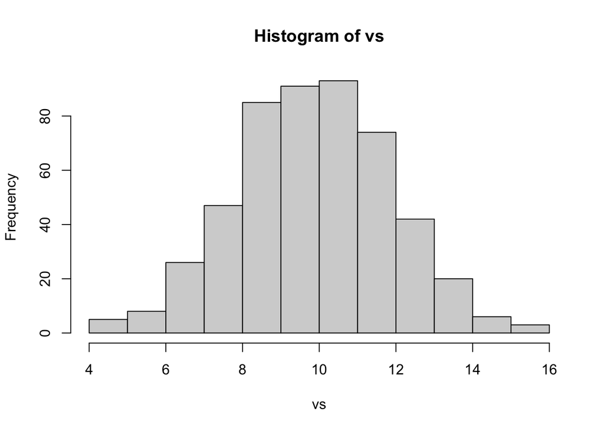

```r
hist( vs )
```

The `hist` function has many arguments to customize the plot. For example (check `?hist` for more details):

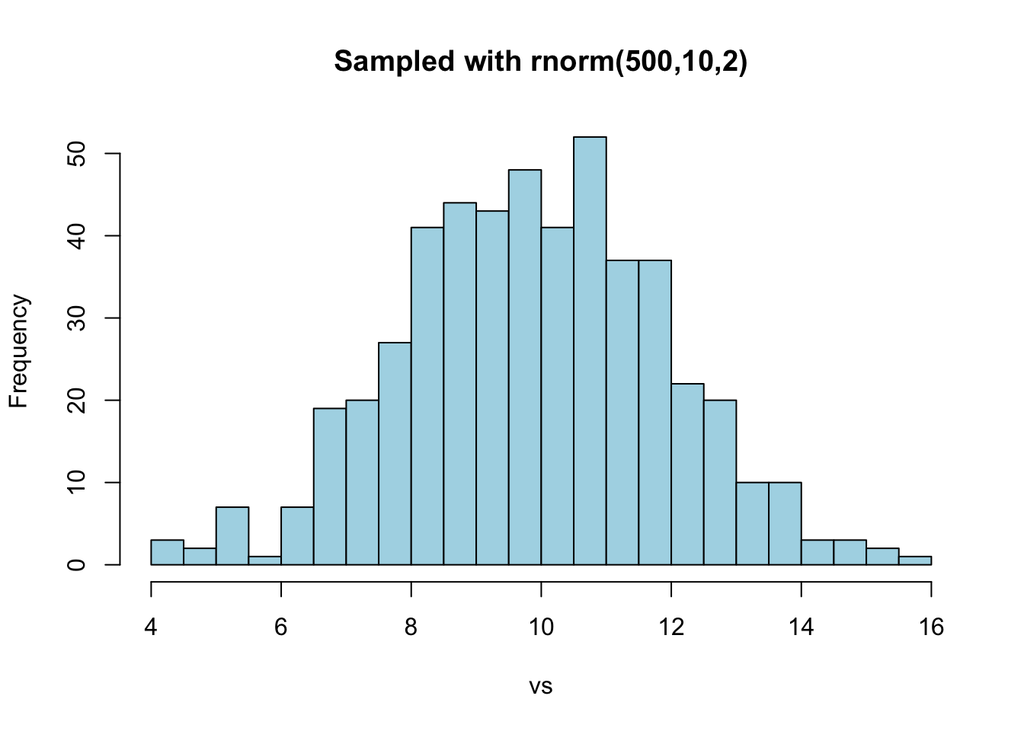

```r
hist( vs, breaks=20, col="lightblue", main="Sampled with rnorm(500,10,2)" )
```

The `quantile` function can be used to calculate quantiles of the data (using many different methods). For example, to calculate the 0, 0.1, 0.25, 0.5, 0.75, 0.9 and 1 quantiles:

```r
quantile( vs, c(0, 0.1, 0.25, 0.5, 0.75, 0.9, 1) )
```

```
       0%       10%       25%       50%       75%       90%      100%
 4.186621  7.279926  8.495278  9.856610 11.283587 12.449859 15.546027
```

Compare the calculated quantiles with:

```r
min( vs )       # quantile 0
```

```
[1] 4.186621
```

```r
median( vs )    # quantile 0.5
```

```
[1] 9.85661
```

```r
max( vs )       # quantile 1
```

```
[1] 15.54603
```

## Factors (lecture) 👩‍🏫

*Needs:* “Vectors”, NA, length, str, c, “[…]”, NA.  
*Gives:* “Factors”, levels, nlevels, as.integer, table, names.

A **factor** is a vector of categorical values (values chosen from a set of predefined possibilities, called **levels**).

For example, a factor can be used to store hair color of some people. Let’s assume that we can classify each person to one of the following hair colors. This will be the **levels** of the factor:

```r
c( "black", "brown", "ginger", "blond", "gray", "white" )
```

Now, let’s assume that for 10 people we observed the following hair colors.  
`NA` (not available, missing value) stands for a person whose hair color could not be determined.  
This will be the **values** of the factor:

```r
c("brown","ginger","black","brown",NA,"brown","black","brown","blond","gray")
```

To **create the factor** and store it in a variable `hairColors`, do:

```r
hairColors <- factor(
  c("brown","ginger","black","brown",NA,"brown","black","brown","blond","gray"),
  levels = c( "black", "brown", "ginger", "blond", "gray", "white" )
)
hairColors
```

```
 [1] brown  ginger black  brown  <NA>   brown  black  brown  blond  gray
Levels: black brown ginger blond gray white
```

### Factor properties and elements

A short presentation of a factor can be obtained with the `str` function:

```r
str( hairColors )
```

```
 Factor w/ 6 levels "black","brown",..: 2 3 1 2 NA 2 1 2 4 5
```

The length of the factor is the number of observations:

```r
length( hairColors )
```

```
[1] 10
```

And elements of the factor can be accessed by the square bracket operator:

```r
hairColors[ 3:6 ]
```

```
[1] black brown <NA>  brown
Levels: black brown ginger blond gray white
```

Elements of a factor can also have names. For example:

```r
names( hairColors ) <- c( "Alice", "Bob", "Charlie", "Daisy", "Eve",
  "Frank", "George", "Helen", "Ivan", "Jack" )
hairColors
```

```
  Alice     Bob Charlie   Daisy     Eve   Frank  George   Helen    Ivan    Jack
  brown  ginger   black   brown    <NA>   brown   black   brown   blond    gray
Levels: black brown ginger blond gray white
```

Naturally, the names can be used to access the elements:

```r
hairColors[ "Alice" ] <- "ginger"   # this changes the hair color of Alice
hairColors
```

```
  Alice     Bob Charlie   Daisy     Eve   Frank  George   Helen    Ivan    Jack
 ginger  ginger   black   brown    <NA>   brown   black   brown   blond    gray
Levels: black brown ginger blond gray white
```

### Levels and coding

In R each factor is stored as two vectors.  
The first vector codes the levels with subsequent integers: `1=black`, `2=brown`, …  
Type the following to get this vector:

```r
levels( hairColors )
```

```
[1] "black"  "brown"  "ginger" "blond"  "gray"   "white"
```

and to find the **number of factor levels** enter:

```r
nlevels( hairColors )
```

```
[1] 6
```

The second vector keeps integers corresponding to the factor values.  
Try the following and understand the relation of the integers and the levels:

```r
as.integer( hairColors )
```

```
 [1]  3  3  1  2 NA  2  1  2  4  5
```

### Count occurrences

Use the `table` function to count occurrences of each level of a factor:

```r
table( hairColors )
```

```
hairColors
 black  brown ginger  blond   gray  white
     2      3      2      1      1      0
```

```r
occs <- table( hairColors )
occs[ "brown" ]
```

```
brown
    3
```

## A factor from raw data, data cleaning (exercise) 📖

*Needs:* “Vectors”, table, NA.  
*Gives:* “Factors”, factor, addNA.  
*Practices:* factor, addNA, c, NA, table.

### Raw data

Let’s assume, that an expensive survey was conducted, and the participants were asked to fill in one of the following values: `low`, `medium`, `high`. Some participants made typos. The data needs to be cleaned, trying to preserve as much information as possible.

The following chunk of code produces a character vector `vs` with the values obtained from the survey.

```r
vsTxt <- "low low low low medium L low medium medium low low low low low ? low looow low low high low low mediun medium low right low low low medium HIGH low low low low low low low Medium low low low low low high medium low low low medium low low low high low low medium low high medium medium low medium high L ?"
vs <- strsplit( vsTxt, " " )[[1]]  # split the text into words, will be introduced later
vs[10] <- NA
head( vs, 16 ) # the first 16 responses
```

```
 [1] "low"    "low"    "low"    "low"    "medium" "L"      "low"    "medium"
 [9] "medium" NA       "low"    "low"    "low"    "low"    "?"      "low"
```

### Building a factor

The goal is to create a factor `fs` from the corrected values of the `vs` vector:

- Print, how many raw responses are there.
- Create the factor with the levels specified in the `"low"`, `"medium"`, `"high"` order.
- Use the `addNA` function to add the `NA` level.
- Finally, print the counts of each of the levels in the factor.

Modifications of the raw input are not allowed (don’t correct the words in `vsTxt` manually). Instead, create a **named** character vector `m` with names corresponding to the raw spelling, and values corresponding to the correct levels, e.g. `m <- c( "HIGH"="high", ... )`. Then, map the `vs` vector through `m` using the square bracket operator. When you can’t decide what should be the level, use `NA`.

*Note:* For a tidyverse solution, you could use `fct_count` to count the levels, `fct_collapse` to map the words to correct levels, `fct_relevel` to reorder the levels.

**Solution…**

```r
### base-R variant
length( vs )
table( vs )
m <- c( "?"=NA, "high"="high", "HIGH"="high", "medium"="medium", "mediun"="medium", "Medium"="medium", "looow"="low", "low"="low", "L"="low" )
table( m[ vs ] )
fs <- factor( m[ vs ], levels = c( "low", "medium", "high" ) )
fs <- addNA( fs )
table( fs )

### tidyverse variant
fs <- factor( vs )
fct_count( fs )
fs <- fct_collapse( fs, low = c( "L", "low", "looow" ), medium = c( "medium", "Medium", "mediun" ), high = c( "HIGH", "high" ), other_level = NA )
fct_count( fs )
fs <- fct_relevel( fs, "low", "medium", "high" )
fct_count( fs )
```

## Generate sample of female heights (exercise) 📖

*Needs:* “Vectors”, “RelOps”, round, rnorm, names, mean, sd, hist, sort, quantile.  
*Gives:* sample.  
*Practices:* rnorm, round, sample, names, mean, sd, hist, sort, head, quantile.

Let’s assume that you are expected to work with data describing heights of female students.  
The real data is not available yet, so you need to generate a random sample.

### Generate

Generate a named vector `heights`:

- There should be `studentsNum` elements in the vector.
- Values should be sampled from the normal distribution with a mean `femaleMeanHeight` and a standard deviation `femaleSdHeight`.
- Names should be randomly sampled from the provided `femaleNames` vector. Find out how to use the `sample` function to perform this task.

```r
studentsNum <- 30
femaleMeanHeight <- 170.7 # cm
femaleSdHeight <- 6.3     # cm
femaleNamesTxt <- "Anastasia,Melissa,Nora,Marlene,Isabel,Eleonora,Amelie,Katharina,Leonie,Sophie,Zoe,Vera,Julia,Magdalena,Elena,Karina,Serena,Viviana,Carmen,Ella,Anita,Ines,Beatrice,Susanne,Katja,Yvonne,Noemi,Miranda,Sonja,Clara,Valentina,Luisa,Victoria,Stefanie,Elisabeth,Martina,Sophia,Sara,Lea,Lorena,Patricia,Emma,Tanja,Nicole,Silvana,Martha,Selina,Melanie,Jolanda,Lucia,Isabella,Felicia,Giulia,Marina,Samantha,Jasmin,Lucie,Corina,Luna,Matilda,Jessica,Lena,Francesca,Alessia,Claudia,Lavinia,Nadia,Regina,Carolina,Adriana,Natalie,Nina,Sylvia,Livia,Miriam,Maria,Mia,Diana,Fiona,Patrizia,Helena,Judith,Laura,Gabriela,Liliana,Tara,Selena,Mona,Paula,Valeria,Verena,Tatjana,Ariana,Alina,Anna,Rebecca,Teresa,Marisa,Gloria,Luciana"
femaleNames <- strsplit( femaleNamesTxt, "," )[[1]]
```

**Solution…**

```r
heights <- round( rnorm( n=30, mean=femaleMeanHeight, sd=femaleSdHeight ), 0 )
heights <- setNames( heights, sample( femaleNames, size=length(heights) ) )
heights
```

### Study

Study the generated `heights` vector:

- Find the mean and standard deviation of the `heights`. Are these values far from the parameters used to generate the `heights`?
- Produce the histogram of the `heights`.
- Find the names of students with heights above the sample mean.
- Print the heights and the names of the 5 tallest students (sorted with decreasing heights).
- What are the heights corresponding to the quantiles 0.3 and 0.7?

**Solution…**

```r
hist(heights)
mean(heights)
sd(heights)

names( heights[ heights > mean(heights) ] )
head( sort(heights, decreasing = TRUE), 5 )
quantile( heights, c(0.3, 0.7) )
```

# Data manipulation 1/3

## The pipe operator (lecture) 👨‍🏫

*Needs:* rnorm, mean, round, sum.  
*Gives:* “|>”, “%>%”.

We want to calculate the mean of 100 randomly generated values from the normal distribution and round it to two decimal places. A step by step solution in statements would look like this:

```r
vs <- rnorm(n=100, mean=5, sd=2)
vsMean <- mean(vs)
round(vsMean, 2)
```

where two variables `vs` and `vsMean` were introduced. A more compact solution would be to call the functions in composition without introducing variables such `vs` and `vsMean`:

```r
round( mean(rnorm(n = 100, mean = 5, sd = 2)), 2)
```

R version 4.1.0 introduced the pipe operator `|>` (earlier `%>%` in `magrittr` R package part of `tidyverse`). It allows to write the code in a “chained” manner. The pipe operator passes the result of the left-hand side expression as the first argument of the right-hand side function. The expression `sum(1:10)` is equivalent to `1:10 |> sum()`.

The pipe notation represents the “data flow” in the expression towards the end result, it also corresponds well to the order of the solution to the problem:

```r
rnorm(n=100, mean=5, sd=2) |> mean() |> round(2)
```

The `tidyverse` library is carefully designed to work well with the pipe operator enabling the user to develop complex data manipulation tasks that are compact and readable.

## Tibble (lecture) 👩‍🏫

*Needs:* “Vectors”.  
*Gives:* tibble, “[[”, “[”.

In previous session we imported existing tables as `tibble`, a data type defined in `tidyverse` package. To create a tibble manually in R we use the function `tibble`:

```r
d <- tibble(
    name = c("Gabriela", "Gale", "John", "Guy", "George"),
    sex = c("female", "female", "male", "male", "male"),
    age = c(17, 17, 20, 18, 17))
d
```

```
# A tibble: 5 × 3
  name     sex      age
  <chr>    <chr>  <dbl>
1 Gabriela female    17
2 Gale     female    17
3 John     male      20
4 Guy      male      18
5 George   male      17
```

You can extract variables(columns) as vectors with `[[` and `$`, or as a separate tibble with `[`.

```r
d[["name"]] # <=> d$name : extracts 'name' as a vector
d["name"]   # extracts 'name' as tibble
d[c("name", "age")]
```

Similar to lists, variables in a tibble may be updated with an assignment `<-`:

```r
d["height"] <- rep(NA, nrow(d))        # add variable 'height' with missing values
d["height"] <- NA                      # equivalent (recycling)
d["weight"] <- sample(60:80,nrow(d))   # add 'weight' variable with random values
```

With the `pull` function (tidyverse) we can extract a (named) vector. Recall that we can extract vectors from a tibble with `[[` or `$`, however the advantage of the pull function is that it can be used in a pipe expression.

```r
d[['weight']]                        # <=> d$weight
d |> pull( weight )                  # weight as a vector
d |> pull(var = weight, name = name) # named vector ; Note the argument
                                     # names (see ?pull)
```

## The pipe operator (exercise) 📖

*Needs:* “|>”, “%>%”, sort, tail, mean, round, rnorm, paste.  
*Practices:* “|>”, “%>%”.

Solve the following two tasks using the non-pipe and the pipe versions of the code:

- A vector with first names of some people is given, e.g. `c( "Olga", "Tim", "Melanie", "Erma")`. Sort the names in the reversed alphabetical order and concatenate them into a single string separated by commas (hint: see `paste` for character concatenation).
- A vector of person heights is given, e.g. `hs <- rnorm( n=100, mean=170, sd=10 )`.  
  Calculate the mean height of the 5 tallest persons. Round the result to one decimal place.

**Solution…**

```r
## non-pipe version
# 1
first_names <- c( "Olga", "Tim", "Melanie", "Erma")
first_names_sorted <- sort(first_names, decreasing=TRUE)
paste(first_names_sorted, collapse=", ")

# 2
set.seed(12345)  # set.seed: ensure reproducible sequences of random numbers
sample_normal_dist <- rnorm( n=100, mean=170, sd=10 )
sample_normal_dist_top5 <- tail(sort(sample_normal_dist),5)
round(mean(sample_normal_dist_top5),1)

## pipe version
# 1
c( "Olga", "Tim", "Melanie", "Erma") |> sort(decreasing=TRUE) |> paste( collapse=", " )

# 2
set.seed(12345) # use the same seed 12345 to be comparable with non-pipe version
rnorm( n=100, mean=170, sd=10 ) |> sort() |> tail(5) |> mean() |> round(1)
```

## Tibble (exercise) 📖

**Solution…**

```r
# 1)
exercise_group <- tibble(name=c("Sonja" , "Steven", "Ines", "Robert", "Tim" ),
                         height=c(167, 185, 164, 180, 172),
                         weight=c(56.0, 87.0, 54.0, 80.0, 58.5),
                         exercise=c("high", "high", "low", "moderate", "low")
                  )
# 2)
exercise_group[['sex']] <- c(2,1,2,1,1)

# 3)
#
# Base R solution is used here, try this with 'filter' which will
# be explained later.
#
heights <- exercise_group[["height"]]
females <- exercise_group[["sex"]]==2
males <- exercise_group[["sex"]]==1
mean(heights[males])
mean(heights[females])

# 4)
exercise_group <- tibble(name = c( exercise_group$name, "Eve"),
       height = c( exercise_group$height, 170),
       weight = c( exercise_group$weight, NA),
       exercise = c( exercise_group$exercise, 'high'),
       sex = c( exercise_group$sex, 2)
       )

# 5)
exercise_group |> pull(weight) |> mean(na.rm=TRUE)

# 6)
weight_levels <- exercise_group |> pull(weight, name)
weight_levels[ (exercise_group |> pull(exercise, name)) == "high"]
```

## Select: choosing columns (lecture) 👨‍🏫

*Files:* pulseNA.csv.  
*Needs:* “pulseNA.csv”, read_csv, head, tail, “tidyverse”, “|>”, “%>%”.  
*Gives:* select, rename.

The `select` function (from `tidyverse`) is used to select variables(columns) of a table. Given a table the select can be used to:

- take a collection of variables and simultaneously **reorder** and/or **rename** the variables
- **reshuffle** the variables order

You’ll need to load `tidyverse` library to be able to use `select`, also import the dataset `pulseNA.csv` into the variable `d`:

```r
library(tidyverse)
d <- read_csv("pulseNA.csv", show_col_types=FALSE)
```

Execute the following code and observe the results (note, the `d` table is not modified as there are no assignments to `d`):

```r
d                                                   # all cols, all rows
d |> head()                                         # top rows (default 6)
d |> select( weight, height )                       # 2 columns, all rows
d |> select( gender, weight, height ) |> head(n=3)  # 3 columns, 3 top rows
d |>
  select( gender, weight, height, everything() ) |>
  head(n=3)                                         # top 3 rows of reordered columns
                                                    # Note: |> multi-line statement
d |> select( -id, -name, -year ) |> head()          # no id, name, year columns
d |> tail()                                         # last rows (default 6)
d |> select( WEIGHT=weight, height ) |> tail()      # 2 columns (one renamed)

d |> rename( WEIGHT=weight ) |> tail()              # all columns, but one renamed
```

Note, the lines above do not modify the `d` table. If you want to store a modified table, you need to assign the result to a variable:

```r
smallD <- d |> select( weight, height )
smallD |> head()
```